# Time Series Model for California Restaurant Employees Using Python

### March 4, 2020

Template Credit: Adapted from a template made available by Dr. Jason Brownlee of Machine Learning Mastery. https://machinelearningmastery.com/

SUMMARY: The purpose of this project is to construct a time series prediction model and document the end-to-end steps using a template. The California Full-Service Restaurant Employees dataset is a time series situation where we are trying to forecast future outcomes based on past data points.

ANALYSIS: The baseline prediction (or persistence) for the dataset resulted in an RMSE of 4.056. After performing a grid search for the most optimal ARIMA parameters, the final ARIMA non-seasonal order was (1, 1, 1) with the seasonal order being (2, 0, 1, 12). Furthermore, the chosen model processed the validation data with an RMSE of 1.740, which was better than the baseline model as expected.

CONCLUSION: For this dataset, the chosen ARIMA model achieved a satisfactory result and should be considered for further modeling or actual forecasting.

Dataset Used: FRED: All Employees: Full-Service Restaurants in California (SMU06000007072251101)

Dataset ML Model: Time series forecast with numerical attributes

Dataset Reference: https://fred.stlouisfed.org/series/SMU06000007072251101.

The project aims to touch on the following areas:

- Document a predictive modeling problem end-to-end
- Explore data cleaning and transformation options
- Explore various algorithms for baselining the model performance
- Explore tuning techniques for improving the model performance

A time series predictive modeling project genrally can be broken down into about five major tasks:

1. Define Problem and Acquire Data
2. Inspect and Explore Data
3. Clean and Pre-Process Data
4. Fit and Evaluate Models
5. Finalize Model

## Section 1. Define Problem and Acquire Data

### 1.a) Load Libraries

```python
import numpy as np
import pandas as pd
import matplotlib.pyplot as plt
import seaborn as sns
import os
import math
import smtplib
import pmdarima as pm
import pandas_datareader.data as web
from datetime import datetime
from email.message import EmailMessage
from sklearn.metrics import mean_squared_error
from statsmodels.tsa.statespace.sarimax import SARIMAX
from statsmodels.tsa.stattools import adfuller
from statsmodels.tsa.seasonal import seasonal_decompose
from statsmodels.graphics.tsaplots import plot_acf
from statsmodels.graphics.tsaplots import plot_pacf
```

### 1.b) Set up the controlling parameters and functions

```python
# Create the random seed number for reproducible results
seedNum = 888

# Set up the number of CPU cores available for multi-thread processing
n_jobs = 1

# Set up the verbose flag to print detailed messages for debugging (setting True will activate!)
verbose = False

# Set up the flag to stop sending progress emails (setting to True will send status emails!)
notifyStatus = False
```

```python
# Set up the email notification function
def email_notify(msg_text):
    sender = os.environ.get('MAIL_SENDER')
    receiver = os.environ.get('MAIL_RECEIVER')
    gateway = os.environ.get('SMTP_GATEWAY')
    smtpuser = os.environ.get('SMTP_USERNAME')
    password = os.environ.get('SMTP_PASSWORD')
    if sender==None or receiver==None or gateway==None or smtpuser==None or password==None:
        sys.exit("Incomplete email setup info. Script Processing Aborted!!!")
    msg = EmailMessage()
    msg.set_content(msg_text)
    msg['Subject'] = 'Notification from Python ARIMA Time Series Script'
    msg['From'] = sender
    msg['To'] = receiver
    server = smtplib.SMTP(gateway, 587)
    server.starttls()
    server.login(smtpuser, password)
    server.send_message(msg)
    server.quit()
```

```python
if (notifyStatus): email_notify("Library and Data Loading has begun! "+datetime.now().strftime('%a %B %d, %Y %I:%M:%S %p'))
```

### 1.c) Acquire and Load the Data

```python
startTimeScript = datetime.now()
```

```python
# load the dataset and the necessary data structure
# time_series = pd.read_csv('https://dainesanalytics.com/datasets/time-series-data-library/tsdl200.csv', index_col='idx', parse_dates=True)

# Load the dataset from the Federal Reserve Bank's FRED Database
starting = datetime(1990, 1, 1)
ending = datetime.now()
fred_data = 'SMU06000007072251101'
time_series = web.DataReader(fred_data, 'fred', starting, ending)
time_series.rename(columns={fred_data: 'value'}, inplace=True)

# Sample code for subsetting the time-series data
# time_series = original_series['1986':'1990']
```

```python
target_col = time_series.columns[0]
lower_bound = 'lower ' + target_col
upper_bound = 'upper ' + target_col
print('The target column of the time series is:', target_col)
print('The forecast boundary columns are:', lower_bound, '&', upper_bound)
```

```
The target column of the time series is: value
The forecast boundary columns are: lower value & upper value
```

```python
time_series.info()
```

```
<class 'pandas.core.frame.DataFrame'>
DatetimeIndex: 360 entries, 1990-01-01 to 2019-12-01
Data columns (total 1 columns):
 #   Column  Non-Null Count  Dtype
---  ------  --------------  -----
 0   value   360 non-null    float64
dtypes: float64(1)
memory usage: 5.6 KB
```

```python
time_series.head(10)
```

| DATE | value |
| --- | --- |
| 1990-01-01 | 318.9 |
| 1990-02-01 | 322.0 |
| 1990-03-01 | 325.1 |
| 1990-04-01 | 325.4 |
| 1990-05-01 | 329.2 |
| 1990-06-01 | 332.7 |
| 1990-07-01 | 336.4 |
| 1990-08-01 | 337.8 |
| 1990-09-01 | 334.9 |
| 1990-10-01 | 328.2 |

```python
time_series.tail(10)
```

| DATE | value |
| --- | --- |
| 2019-03-01 | 650.8 |
| 2019-04-01 | 656.2 |
| 2019-05-01 | 661.3 |
| 2019-06-01 | 665.5 |
| 2019-07-01 | 663.3 |
| 2019-08-01 | 660.7 |
| 2019-09-01 | 654.7 |
| 2019-10-01 | 650.7 |
| 2019-11-01 | 649.3 |
| 2019-12-01 | 646.4 |

```python
if (notifyStatus): email_notify("Library and Data Loading completed! "+datetime.now().strftime('%a %B %d, %Y %I:%M:%S %p'))
```

## Section 2. Inspect and Explore Data

```python
if (notifyStatus): email_notify("Data Inspection and Exploration has begun! "+datetime.now().strftime('%a %B %d, %Y %I:%M:%S %p'))
```

### 2.a) Summary Statistics of the Time Series Data

Summary statistics provide a quick look at the limits of observed values. It can help to get a quick idea of what we are working with.

```python
# Summary statistics of time series
print(time_series.describe())
```

```
            value
count  360.000000
mean   483.333611
std    106.015609
min    316.200000
25%    385.825000
50%    484.700000
75%    560.725000
max    665.500000
```

### 2.b) Line Plot of the Time Series Data

A line plot of a time series can provide a lot of insight into the problem. Some observations from the plot can include:

- Whether the trend appears to be level around the mean
- Whether there appear to be any obvious outliers

The ARIMA(p,d,q) model requires three parameters and assumes that we are working with a stationary time series.

The ADF results should show that the test statistic value is smaller than the critical value at 5% if the time series is stationary. This suggests that we can reject the null hypothesis (i.e. a low probability that the result is a statistical fluke).

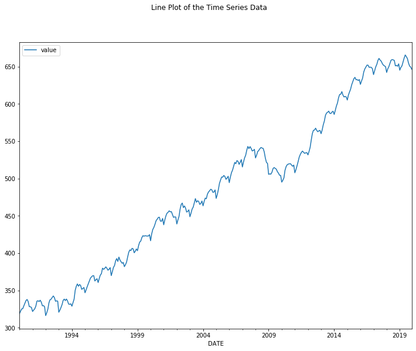

```python
# Line plots of time series
fig, ax = plt.subplots(figsize=(12,9))
fig.suptitle('Line Plot of the Time Series Data')
time_series.plot(ax=ax)
plt.show()
```

### 2.c) Histogram and Density Plots of the Time Series Data

Reviewing plots of the density of observations can provide further insight into the structure of the data. Some observations from the plots can include:

- Whether the distribution is Gaussian
- Whether the distribution has a long tail and may suggest the need for data transformation

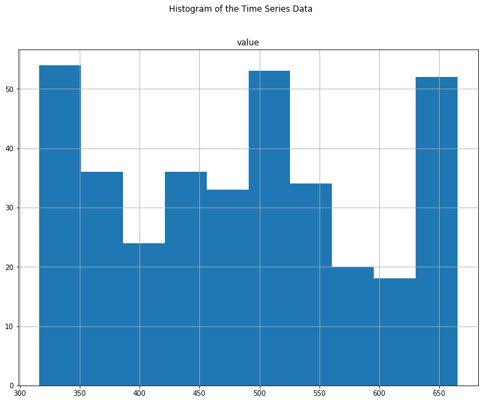

```python
# Line plots of time series
fig, ax = plt.subplots(figsize=(12,9))
fig.suptitle('Histogram of the Time Series Data')
time_series.hist(ax=ax)
plt.show()
```

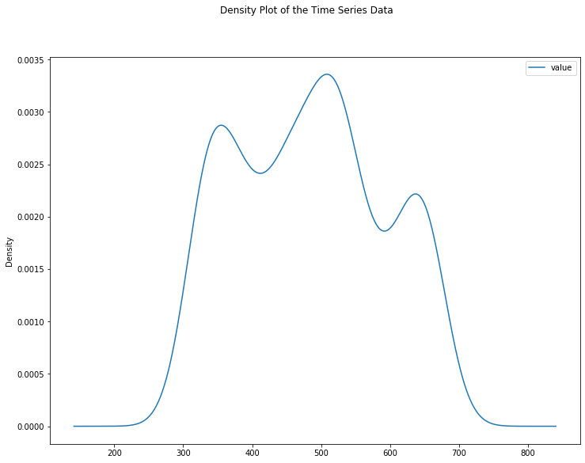

```python
# Line plots of time series
fig, ax = plt.subplots(figsize=(12,9))
fig.suptitle('Density Plot of the Time Series Data')
time_series.plot(kind='kde', ax=ax)
plt.show()
```

### 2.d) Box and Whisker Plots of the Time Series Data

We can group or aggregate the data and get a better idea of the spread of observations. Some observations from reviewing the plot can include:

- Whether the median values for each grouping shows any significant trend
- Whether the spread, or middle 50% of the data, shows any significant variability
- Whether there are outliers in some grouping

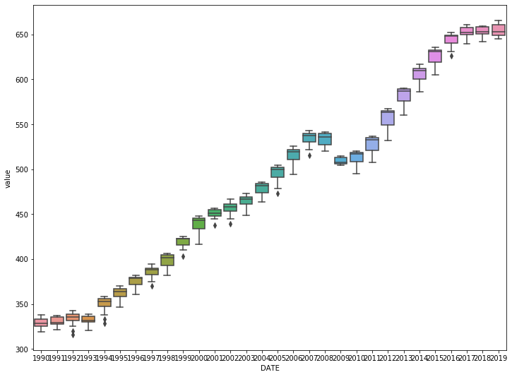

```python
# boxplots of time series
fig, ax = plt.subplots(figsize=(12,9))
squeezed = time_series.squeeze()
sns.boxplot(squeezed.index.year, squeezed, ax=ax)
plt.show()
```

```python
if (notifyStatus): email_notify("Data Inspection and Exploration completed! "+datetime.now().strftime('%a %B %d, %Y %I:%M:%S %p'))
```

## Section 3. Data Transformation and Stationarity Tests

```python
if (notifyStatus): email_notify("Data Cleaning and Pre-Processing has begun! "+datetime.now().strftime('%a %B %d, %Y %I:%M:%S %p'))
```

### Section 3.a) Data Transformation

```python
# Resampling the time series into monthly average for the ease of modeling
# original_series = time_series
# resample = original_series.resample('M')
# time_series = resample.mean()
# time_series.head(10)
```

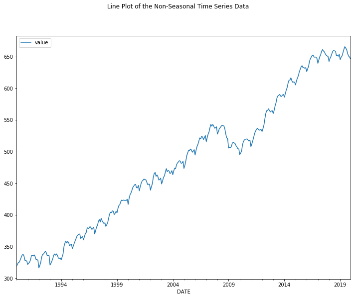

```python
# Line plots of the transformed time series
fig, ax = plt.subplots(figsize=(12,9))
fig.suptitle('Line Plot of the Non-Seasonal Time Series Data')
time_series.plot(ax=ax)
plt.show()
```

### Section 3.b) Test for Stationarity

```python
# Check if stationary
result = adfuller(time_series[target_col])
print('ADF Statistic: %f' % result[0])
print('p-value: %f' % result[1])
print('Critical Test Statistics Values:')
for key, value in result[4].items():
    print('\t%s: %.3f' % (key, value))
```

```
ADF Statistic: -0.847711
p-value: 0.804704
Critical Test Statistics Values:
	1%: -3.450
	5%: -2.870
	10%: -2.571
```

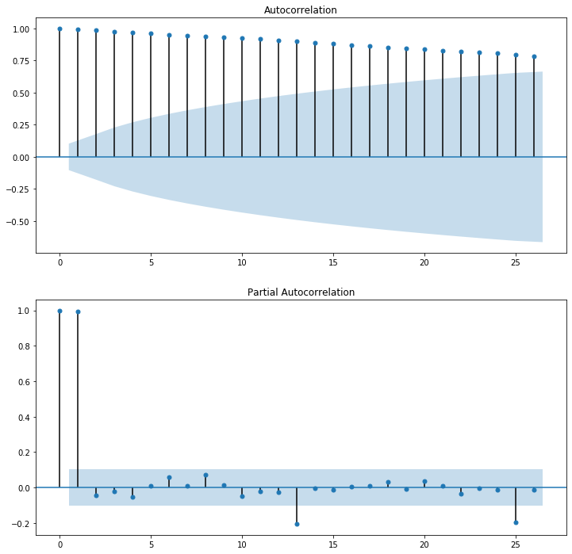

```python
# ACF and PACF plots of the time series data
fig, (ax1, ax2) = plt.subplots(2, 1, figsize=(12,12))
plot_acf(time_series, ax=ax1)
plot_pacf(time_series, ax=ax2)
plt.show()
```

### 3.c) Test for Stationarity of Non-Seasonal Time Series Data

Occasionally a time series may look non-stationary on the first look. We can make it stationary by differencing the series and using a statistical test to confirm that the differenced result is stationary. Rejecting the null hypothesis means that the process has no unit root, and in turn that the time series is stationary or does not have time-dependent structure.

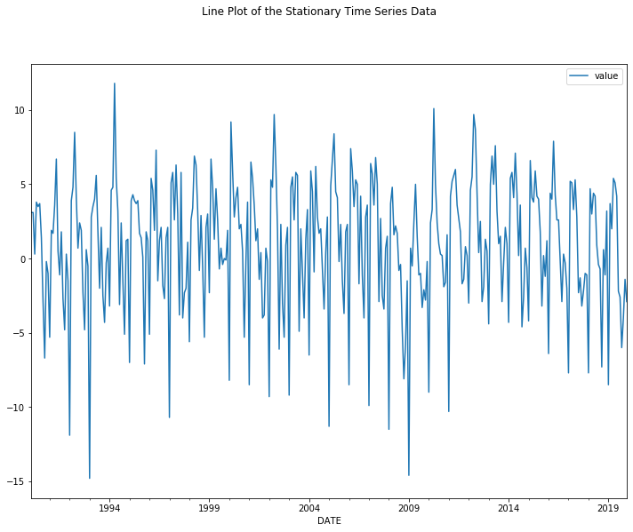

```python
# Create a differenced series
stationary_ns = time_series.diff().dropna()

# Plot differenced data
fig, ax = plt.subplots(figsize=(12,9))
fig.suptitle('Line Plot of the Stationary Time Series Data')
stationary_ns.plot(ax=ax)
plt.show()
```

```python
# Check for stationarity
result = adfuller(stationary_ns[target_col])
print('ADF Statistic: %f' % result[0])
print('p-value: %f' % result[1])
print('Critical Test Statistics Values:')
for key, value in result[4].items():
    print('\t%s: %.3f' % (key, value))
```

```
ADF Statistic: -2.942348
p-value: 0.040640
Critical Test Statistics Values:
	1%: -3.450
	5%: -2.870
	10%: -2.571
```

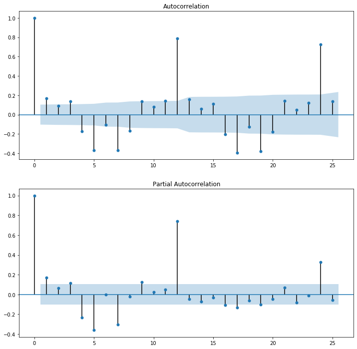

```python
# ACF and PACF plots of the stationary time series
lags = 25
fig, (ax1, ax2) = plt.subplots(2, 1, figsize=(12,12))
plot_acf(stationary_ns, lags=lags, ax=ax1)
plot_pacf(stationary_ns, lags=lags, ax=ax2)
plt.show()
```

### 3.d) Seasonal Decomposition for Seasonal Time Series Data

```python
# Set the initial seasonal frequency parameter
seasonal_freq = 12
```

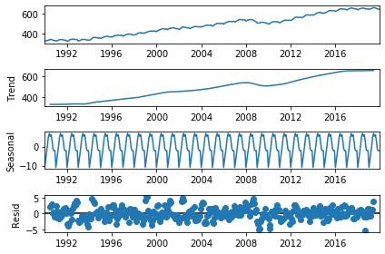

```python
# Perform seasonal decomposition to observe the seasonal frequency
decomp_results = seasonal_decompose(time_series, freq=seasonal_freq)
decomp_results.plot()
plt.show()
```

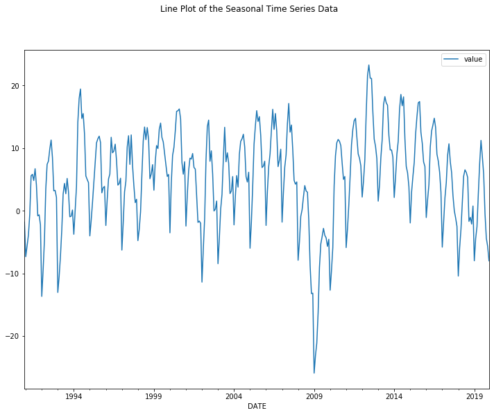

```python
# Create a seasonal series
N = seasonal_freq
seasonal_series = time_series - time_series.rolling(N).mean()
seasonal_series = seasonal_series.dropna()

# Line plots of the seasonal time series
fig, ax = plt.subplots(figsize=(12,9))
fig.suptitle('Line Plot of the Seasonal Time Series Data')
seasonal_series.plot(ax=ax)
plt.show()
```

```python
# Check for stationarity
result = adfuller(seasonal_series[target_col])
print('ADF Statistic: %f' % result[0])
print('p-value: %f' % result[1])
print('Critical Test Statistics Values:')
for key, value in result[4].items():
    print('\t%s: %.3f' % (key, value))
```

```
ADF Statistic: -4.064948
p-value: 0.001106
Critical Test Statistics Values:
	1%: -3.450
	5%: -2.870
	10%: -2.571
```

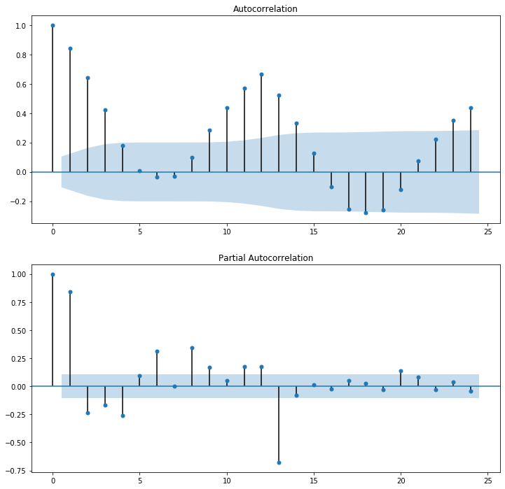

```python
# ACF and PACF plots of the time series data
lag = seasonal_freq * 2
fig, (ax1, ax2) = plt.subplots(2, 1, figsize=(12,12))
plot_acf(seasonal_series, lags=lag, ax=ax1)
plot_pacf(seasonal_series, lags=lag, ax=ax2)
plt.show()
```

### 3.e) Test for Stationarity of Seasonal Time Series Data

Occasionally a time series may look non-stationary on the first look. We can make it stationary by differencing the series and using a statistical test to confirm that the differenced result is stationary. Rejecting the null hypothesis means that the process has no unit root, and in turn that the time series is stationary or does not have time-dependent structure.

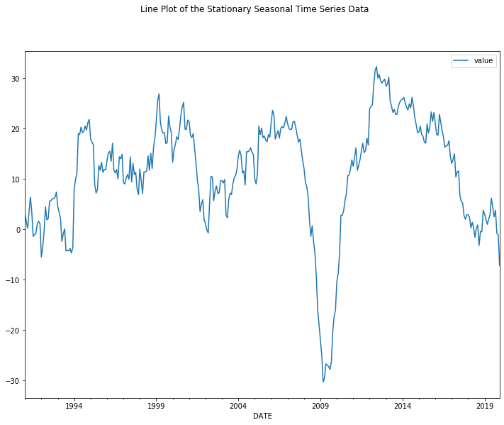

```python
# Create a differenced series
stationary_ss = time_series.diff(seasonal_freq).dropna()

# Plot differenced data
fig, ax = plt.subplots(figsize=(12,9))
fig.suptitle('Line Plot of the Stationary Seasonal Time Series Data')
stationary_ss.plot(ax=ax)
plt.show()
```

```python
# Check for stationarity
result = adfuller(stationary_ss[target_col])
print('ADF Statistic: %f' % result[0])
print('p-value: %f' % result[1])
print('Critical Test Statistics Values:')
for key, value in result[4].items():
    print('\t%s: %.3f' % (key, value))
```

```
ADF Statistic: -2.395379
p-value: 0.143045
Critical Test Statistics Values:
	1%: -3.450
	5%: -2.870
	10%: -2.571
```

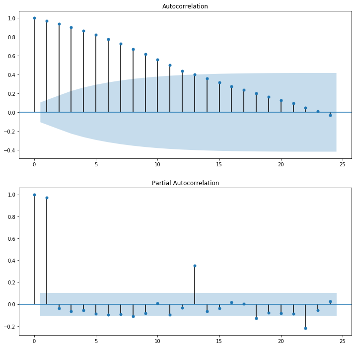

```python
# ACF and PACF plots of the stationary time series
lags = seasonal_freq * 2
fig, (ax1, ax2) = plt.subplots(2, 1, figsize=(12,12))
plot_acf(stationary_ss, lags=lags, ax=ax1)
plot_pacf(stationary_ss, lags=lags, ax=ax2)
plt.show()
```

```python
if (notifyStatus): email_notify("Data Cleaning and Pre-Processing completed! "+datetime.now().strftime('%a %B %d, %Y %I:%M:%S %p'))
```

## Section 4. Fit and Evaluate Models

In this section, we will develop Autoregressive Integrated Moving Average or ARIMA models for the problem. We will first establish a persistent model. Next we will use a grid search approach to look for an optimal ARIMA model. This will be followed by a third step of investigating the residual errors of the chosen model.

- Establish the Persistent Model
- Automatically Configure the ARIMA
- Review Residual Errors

```python
if (notifyStatus): email_notify("Model Fitting and Evaluation has begun! "+datetime.now().strftime('%a %B %d, %Y %I:%M:%S %p'))
```

### 4.a) Establish the Persistent Model

The first step before getting bogged down in data analysis and modeling is to establish a baseline of performance. This will provide both a template for evaluating models using the proposed test harness and a performance measure by which all more elaborate predictive models can be compared.

The baseline prediction for time series forecasting is called the naive forecast, or persistence. This is where the observation from the previous time step is used as the prediction for the observation at the next time step.

#### 4.a.iii) Establish the Persistent Model as Baseline

```python
# Prepare and evaluate a persistence model
X = time_series.values
X = X.astype('float32')
train_pct = 0.80
train_size = int(len(X) * train_pct)
test_size = len(X) - train_size
train_ts, test_ts = X[0:train_size], X[train_size:]

# walk-forward validation
history = [x for x in train_ts]
predictions = list()
for i in range(len(test_ts)):
    yhat = history[-1]
    predictions.append(yhat)
    obs = test_ts[i]
    history.append(obs)
    print('>Predicted=%.3f, Expected=%3.f' % (yhat, obs))

# Calculate performance
rmse = math.sqrt(mean_squared_error(test_ts, predictions))
print('RMSE for the persistent model is: %.3f' % rmse)
```

```
>Predicted=590.100, Expected=586
>Predicted=585.800, Expected=591
>Predicted=591.200, Expected=597
>Predicted=597.000, Expected=601
>Predicted=601.100, Expected=608
>Predicted=608.200, Expected=613
>Predicted=612.600, Expected=613
>Predicted=612.800, Expected=616
>Predicted=616.400, Expected=612
>Predicted=611.800, Expected=609
>Predicted=609.200, Expected=610
>Predicted=609.900, Expected=609
>Predicted=609.300, Expected=605
>Predicted=605.100, Expected=612
>Predicted=611.700, Expected=616
>Predicted=615.800, Expected=620
>Predicted=619.600, Expected=626
>Predicted=625.500, Expected=630
>Predicted=629.700, Expected=634
>Predicted=633.700, Expected=636
>Predicted=635.500, Expected=632
>Predicted=632.300, Expected=632
>Predicted=632.500, Expected=631
>Predicted=631.300, Expected=632
>Predicted=632.500, Expected=626
>Predicted=626.100, Expected=630
>Predicted=630.500, Expected=634
>Predicted=634.500, Expected=642
>Predicted=642.400, Expected=647
>Predicted=646.700, Expected=649
>Predicted=649.300, Expected=652
>Predicted=651.900, Expected=652
>Predicted=651.800, Expected=649
>Predicted=648.900, Expected=649
>Predicted=649.200, Expected=649
>Predicted=648.900, Expected=647
>Predicted=646.900, Expected=639
>Predicted=639.200, Expected=644
>Predicted=644.400, Expected=650
>Predicted=649.500, Expected=653
```

[output cut: 18 more lines]

```
>Predicted=651.500, Expected=650
>Predicted=650.400, Expected=654
>Predicted=653.600, Expected=645
>Predicted=645.100, Expected=649
>Predicted=648.800, Expected=651
>Predicted=650.800, Expected=656
>Predicted=656.200, Expected=661
>Predicted=661.300, Expected=666
>Predicted=665.500, Expected=663
>Predicted=663.300, Expected=661
>Predicted=660.700, Expected=655
>Predicted=654.700, Expected=651
>Predicted=650.700, Expected=649
>Predicted=649.300, Expected=646
RMSE for the persistent model is: 4.056
```

### 4.b) Grid Search of ARIMA Hyperparameters

We want to find a model that can do better than the persistence model on this dataset. To confirm this analysis, we can grid search a suite of ARIMA hyperparameters.

In this section, we will search values of p, d, and q for combinations (skipping those that fail to converge), and find the combination that results in the best performance. We will use a grid search to explore all combinations in a subset of integer values.

```python
if (notifyStatus): email_notify("ARIMA Hyperparameters Search has begun! "+datetime.now().strftime('%a %B %d, %Y %I:%M:%S %p'))
```

```python
# Set the initial P, D, and Q order parameters for non-seasonal ARIMA modeling
start_p = 0
start_d = None
start_q = 0
max_p = 5
max_d = 2
max_q = 5
```

```python
# Set the initial P, D, and Q order parameters for seasonal ARIMA modeling
start_P = 0
start_D = None
start_Q = 0
max_P = 2
max_D = 1
max_Q = 2
```

```python
# Testing the time series data for suggestions on the differencing term
start_d = pm.arima.ndiffs(train_ts)
print('The suggested non-seasonal differencing term is:', start_d)
if (seasonal_freq != 0):
    start_D = pm.arima.nsdiffs(train_ts, m = seasonal_freq)
    print('The suggested seasonal differencing term is:', start_D)
```

```
The suggested non-seasonal differencing term is: 1
The suggested seasonal differencing term is: 0
```

```python
print('The initial non-seasonal parameters are: p =', start_p, '| d =', start_d, '| q =', start_q)
print('The maximum non-seasonal parameters are: max_p =', max_p, '| max_d =', max_d, '| max_q =', max_q)
if (seasonal_freq != 0):
    print('The initial seasonal parameters are: P =', start_P, '| D =', start_D, '| Q =', start_Q, '| m =', seasonal_freq)
    print('The maximum seasonal parameters are: max_P =', max_P, '| max_D =', max_D, '| max_Q =', max_Q)
```

```
The initial non-seasonal parameters are: p = 0 | d = 1 | q = 0
The maximum non-seasonal parameters are: max_p = 5 | max_d = 2 | max_q = 5
The initial seasonal parameters are: P = 0 | D = 0 | Q = 0 | m = 12
The maximum seasonal parameters are: max_P = 2 | max_D = 1 | max_Q = 2
```

```python
# Do an automated stepwise search of ARIMA parameters
if (seasonal_freq == 0):
    stepwise_results = pm.auto_arima(train_ts, seasonal = False, stepwise = True, trace = True, suppress_warnings = True, random_state = seedNum)
else:
    stepwise_results = pm.auto_arima(train_ts, seasonal = True, m = seasonal_freq, stepwise = True, trace = True, suppress_warnings = True, random_state = seedNum)
```

```
Performing stepwise search to minimize aic
Fit ARIMA: (2, 1, 2)x(1, 0, 1, 12) (constant=True); AIC=1297.252, BIC=1326.528, Time=5.219 seconds
Fit ARIMA: (0, 1, 0)x(0, 0, 0, 12) (constant=True); AIC=1670.333, BIC=1677.652, Time=0.044 seconds
Fit ARIMA: (1, 1, 0)x(1, 0, 0, 12) (constant=True); AIC=1382.195, BIC=1396.833, Time=0.625 seconds
Fit ARIMA: (0, 1, 1)x(0, 0, 1, 12) (constant=True); AIC=1523.328, BIC=1537.965, Time=0.797 seconds
Fit ARIMA: (0, 1, 0)x(0, 0, 0, 12) (constant=False); AIC=1681.212, BIC=1684.871, Time=0.041 seconds
Fit ARIMA: (2, 1, 2)x(0, 0, 1, 12) (constant=True); AIC=1464.918, BIC=1490.534, Time=4.362 seconds
Near non-invertible roots for order (2, 1, 2)(0, 0, 1, 12); setting score to inf (at least one inverse root too close to the border of the unit circle: 1.000)
Fit ARIMA: (2, 1, 2)x(1, 0, 0, 12) (constant=True); AIC=1385.091, BIC=1410.708, Time=4.320 seconds
Fit ARIMA: (2, 1, 2)x(2, 0, 1, 12) (constant=True); AIC=1299.920, BIC=1332.856, Time=11.455 seconds
Fit ARIMA: (2, 1, 2)x(1, 0, 2, 12) (constant=True); AIC=1300.344, BIC=1333.279, Time=10.205 seconds
Near non-invertible roots for order (2, 1, 2)(1, 0, 2, 12); setting score to inf (at least one inverse root too close to the border of the unit circle: 0.991)
Fit ARIMA: (2, 1, 2)x(0, 0, 0, 12) (constant=True); AIC=1652.712, BIC=1674.669, Time=1.239 seconds
Fit ARIMA: (2, 1, 2)x(0, 0, 2, 12) (constant=True); AIC=1428.815, BIC=1458.091, Time=7.446 seconds
Near non-invertible roots for order (2, 1, 2)(0, 0, 2, 12); setting score to inf (at least one inverse root too close to the border of the unit circle: 0.996)
Fit ARIMA: (2, 1, 2)x(2, 0, 0, 12) (constant=True); AIC=1352.566, BIC=1381.842, Time=9.423 seconds
Fit ARIMA: (2, 1, 2)x(2, 0, 2, 12) (constant=True); AIC=1301.383, BIC=1337.978, Time=10.201 seconds
Near non-invertible roots for order (2, 1, 2)(2, 0, 2, 12); setting score to inf (at least one inverse root too close to the border of the unit circle: 0.994)
Fit ARIMA: (1, 1, 2)x(1, 0, 1, 12) (constant=True); AIC=1298.192, BIC=1323.809, Time=4.581 seconds
Fit ARIMA: (2, 1, 1)x(1, 0, 1, 12) (constant=True); AIC=1295.919, BIC=1321.535, Time=6.436 seconds
Near non-invertible roots for order (2, 1, 1)(1, 0, 1, 12); setting score to inf (at least one inverse root too close to the border of the unit circle: 0.994)
Fit ARIMA: (3, 1, 2)x(1, 0, 1, 12) (constant=True); AIC=1312.422, BIC=1345.357, Time=6.182 seconds
Near non-invertible roots for order (3, 1, 2)(1, 0, 1, 12); setting score to inf (at least one inverse root too close to the border of the unit circle: 0.999)
Fit ARIMA: (2, 1, 3)x(1, 0, 1, 12) (constant=True); AIC=1303.016, BIC=1335.951, Time=6.489 seconds
Fit ARIMA: (1, 1, 1)x(1, 0, 1, 12) (constant=True); AIC=1296.401, BIC=1318.358, Time=4.591 seconds
Fit ARIMA: (1, 1, 1)x(0, 0, 1, 12) (constant=True); AIC=1524.469, BIC=1542.767, Time=1.202 seconds
Fit ARIMA: (1, 1, 1)x(1, 0, 0, 12) (constant=True); AIC=1382.111, BIC=1400.408, Time=1.356 seconds
Fit ARIMA: (1, 1, 1)x(2, 0, 1, 12) (constant=True); AIC=1295.463, BIC=1321.079, Time=9.480 seconds
Fit ARIMA: (1, 1, 1)x(2, 0, 0, 12) (constant=True); AIC=1349.499, BIC=1371.456, Time=3.744 seconds
Fit ARIMA: (1, 1, 1)x(2, 0, 2, 12) (constant=True); AIC=1298.494, BIC=1327.770, Time=12.484 seconds
Near non-invertible roots for order (1, 1, 1)(2, 0, 2, 12); setting score to inf (at least one inverse root too close to the border of the unit circle: 0.999)
Fit ARIMA: (1, 1, 1)x(1, 0, 2, 12) (constant=True); AIC=1298.113, BIC=1323.730, Time=9.610 seconds
Fit ARIMA: (0, 1, 1)x(2, 0, 1, 12) (constant=True); AIC=1303.838, BIC=1325.795, Time=7.267 seconds
Near non-invertible roots for order (0, 1, 1)(2, 0, 1, 12); setting score to inf (at least one inverse root too close to the border of the unit circle: 0.996)
Fit ARIMA: (1, 1, 0)x(2, 0, 1, 12) (constant=True); AIC=1303.068, BIC=1325.025, Time=7.778 seconds
Near non-invertible roots for order (1, 1, 0)(2, 0, 1, 12); setting score to inf (at least one inverse root too close to the border of the unit circle: 0.997)
Fit ARIMA: (2, 1, 1)x(2, 0, 1, 12) (constant=True); AIC=1297.981, BIC=1327.257, Time=12.607 seconds
Fit ARIMA: (1, 1, 2)x(2, 0, 1, 12) (constant=True); AIC=1302.616, BIC=1331.892, Time=11.014 seconds
Fit ARIMA: (0, 1, 0)x(2, 0, 1, 12) (constant=True); AIC=1306.062, BIC=1324.360, Time=7.365 seconds
Near non-invertible roots for order (0, 1, 0)(2, 0, 1, 12); setting score to inf (at least one inverse root too close to the border of the unit circle: 0.997)
Fit ARIMA: (0, 1, 2)x(2, 0, 1, 12) (constant=True); AIC=1304.424, BIC=1330.040, Time=7.269 seconds
Near non-invertible roots for order (0, 1, 2)(2, 0, 1, 12); setting score to inf (at least one inverse root too close to the border of the unit circle: 0.996)
Fit ARIMA: (2, 1, 0)x(2, 0, 1, 12) (constant=True); AIC=1302.454, BIC=1328.070, Time=9.521 seconds
Near non-invertible roots for order (2, 1, 0)(2, 0, 1, 12); setting score to inf (at least one inverse root too close to the border of the unit circle: 0.997)
Total fit time: 194.465 seconds
```

```
                                     SARIMAX Results
==========================================================================================
Dep. Variable:                                  y   No. Observations:                  288
Model:             SARIMAX(1, 1, 1)x(2, 0, 1, 12)   Log Likelihood                -640.731
Date:                            Tue, 25 Feb 2020   AIC                           1295.463
Time:                                    03:38:38   BIC                           1321.079
Sample:                                         0   HQIC                          1305.729
                                            - 288
Covariance Type:                              opg
==============================================================================
                 coef    std err          z      P>|z|      [0.025      0.975]
------------------------------------------------------------------------------
intercept      0.0003      0.001      0.288      0.773      -0.002       0.002
ar.L1          0.9012      0.079     11.412      0.000       0.746       1.056
ma.L1         -0.7878      0.114     -6.899      0.000      -1.012      -0.564
ar.S.L12       1.0703      0.078     13.806      0.000       0.918       1.222
ar.S.L24      -0.0733      0.076     -0.968      0.333      -0.222       0.075
ma.S.L12      -0.8776      0.069    -12.632      0.000      -1.014      -0.741
sigma2         4.7465      0.383     12.383      0.000       3.995       5.498
===================================================================================
Ljung-Box (Q):                       43.02   Jarque-Bera (JB):                22.21
Prob(Q):                              0.34   Prob(JB):                         0.00
Heteroskedasticity (H):               0.71   Skew:                            -0.02
Prob(H) (two-sided):                  0.09   Kurtosis:                         4.36
===================================================================================

Warnings:
[1] Covariance matrix calculated using the outer product of gradients (complex-step).
```

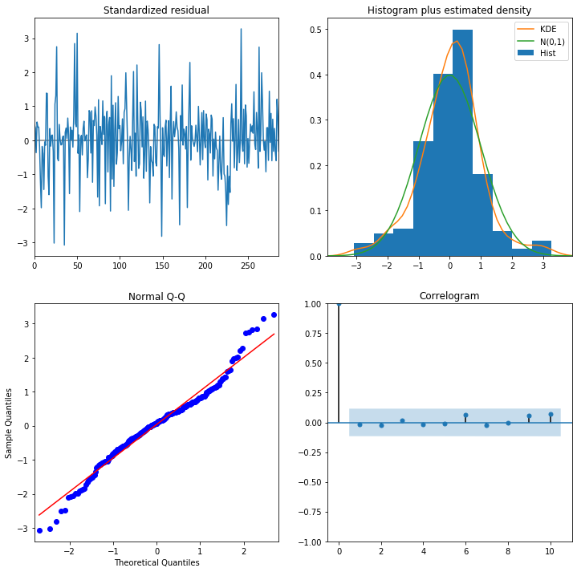

```python
# Summarize residual errors for the automated grid search ARIMA model
print(stepwise_results.summary())
stepwise_results.plot_diagnostics(figsize=(12,12))
plt.show()
```

```python
if (notifyStatus): email_notify("ARIMA automated stepwise search completed! "+datetime.now().strftime('%a %B %d, %Y %I:%M:%S %p'))
```

```python
# Do an automated random search of ARIMA parameters
n_fits = int(max_p * max_d * max_q * max_P * max_D * max_Q * 0.30)
if (seasonal_freq == 0):
    randgrid_results = pm.auto_arima(train_ts, start_p = start_p, d = start_d, start_q = start_q, max_p = max_p, max_d = max_d, max_q = max_q,
                                     seasonal = False, stepwise = False, random = True, n_fits = n_fits, max_order = None,
                                     trace = True, suppress_warnings = True, random_state = seedNum)
else:
    randgrid_results = pm.auto_arima(train_ts, start_p = start_p, d = start_d, start_q = start_q, max_p = max_p, max_d = max_d, max_q = max_q,
                                     seasonal = True, m = seasonal_freq, start_P = start_P, D = start_D, start_Q = start_Q, max_P = max_P, max_D = max_D, max_Q = max_Q,
                                     stepwise = False, random = True, n_fits = n_fits, max_order = None,
                                     trace = True, suppress_warnings = True, random_state = seedNum)
```

```
Fit ARIMA: (3, 1, 4)x(1, 0, 1, 12) (constant=True); AIC=1303.665, BIC=1343.919, Time=7.228 seconds
Fit ARIMA: (5, 1, 0)x(2, 0, 1, 12) (constant=True); AIC=1302.639, BIC=1339.234, Time=14.122 seconds
Fit ARIMA: (5, 1, 5)x(2, 0, 0, 12) (constant=True); AIC=1351.070, BIC=1402.303, Time=19.916 seconds
Fit ARIMA: (1, 1, 0)x(0, 0, 2, 12) (constant=True); AIC=1457.201, BIC=1475.499, Time=1.989 seconds
Fit ARIMA: (2, 1, 3)x(1, 0, 1, 12) (constant=True); AIC=1303.016, BIC=1335.951, Time=5.945 seconds
Fit ARIMA: (1, 1, 0)x(0, 0, 0, 12) (constant=True); AIC=1666.049, BIC=1677.027, Time=0.151 seconds
Fit ARIMA: (1, 1, 0)x(0, 0, 1, 12) (constant=True); AIC=1523.208, BIC=1537.846, Time=0.675 seconds
Fit ARIMA: (3, 1, 5)x(2, 0, 2, 12) (constant=True); AIC=1314.365, BIC=1365.597, Time=17.100 seconds
Fit ARIMA: (1, 1, 4)x(0, 0, 1, 12) (constant=True); AIC=1508.584, BIC=1537.860, Time=5.713 seconds
Fit ARIMA: (1, 1, 0)x(1, 0, 1, 12) (constant=True); AIC=1307.052, BIC=1325.349, Time=2.288 seconds
Fit ARIMA: (2, 1, 1)x(2, 0, 0, 12) (constant=True); AIC=1351.468, BIC=1377.085, Time=5.332 seconds
Fit ARIMA: (1, 1, 5)x(2, 0, 2, 12) (constant=True); AIC=1308.425, BIC=1352.339, Time=20.122 seconds
Fit ARIMA: (3, 1, 3)x(0, 0, 1, 12) (constant=True); AIC=1481.950, BIC=1514.885, Time=6.448 seconds
Fit ARIMA: (2, 1, 2)x(1, 0, 2, 12) (constant=True); AIC=1300.344, BIC=1333.279, Time=10.519 seconds
Fit ARIMA: (1, 1, 3)x(0, 0, 2, 12) (constant=True); AIC=1459.689, BIC=1488.965, Time=6.155 seconds
Fit ARIMA: (1, 1, 5)x(1, 0, 1, 12) (constant=True); AIC=1301.417, BIC=1338.012, Time=7.852 seconds
Fit ARIMA: (5, 1, 5)x(0, 0, 1, 12) (constant=True); AIC=1398.743, BIC=1446.316, Time=11.112 seconds
Fit ARIMA: (4, 1, 3)x(0, 0, 0, 12) (constant=True); AIC=1553.765, BIC=1586.700, Time=2.885 seconds
Fit ARIMA: (1, 1, 4)x(1, 0, 2, 12) (constant=True); AIC=1298.640, BIC=1335.235, Time=14.521 seconds
Fit ARIMA: (4, 1, 4)x(2, 0, 0, 12) (constant=True); AIC=1360.924, BIC=1404.838, Time=15.925 seconds
Fit ARIMA: (1, 1, 2)x(0, 0, 1, 12) (constant=True); AIC=1526.336, BIC=1548.292, Time=1.147 seconds
Fit ARIMA: (4, 1, 4)x(1, 0, 0, 12) (constant=True); AIC=1375.863, BIC=1416.117, Time=7.237 seconds
Fit ARIMA: (3, 1, 0)x(2, 0, 2, 12) (constant=True); AIC=1302.210, BIC=1335.146, Time=10.630 seconds
Fit ARIMA: (2, 1, 5)x(1, 0, 1, 12) (constant=True); AIC=1303.083, BIC=1343.338, Time=8.636 seconds
Fit ARIMA: (3, 1, 1)x(1, 0, 1, 12) (constant=True); AIC=1297.060, BIC=1326.336, Time=5.186 seconds
Fit ARIMA: (3, 1, 4)x(1, 0, 2, 12) (constant=True); AIC=1303.179, BIC=1347.093, Time=18.377 seconds
Fit ARIMA: (3, 1, 5)x(1, 0, 2, 12) (constant=True); AIC=1307.262, BIC=1354.835, Time=19.863 seconds
Fit ARIMA: (4, 1, 4)x(1, 0, 1, 12) (constant=True); AIC=1306.827, BIC=1350.741, Time=8.979 seconds
Fit ARIMA: (3, 1, 0)x(0, 0, 2, 12) (constant=True); AIC=1458.710, BIC=1484.326, Time=2.715 seconds
Fit ARIMA: (3, 1, 5)x(0, 0, 2, 12) (constant=True); AIC=1454.607, BIC=1498.520, Time=18.336 seconds
Fit ARIMA: (3, 1, 1)x(1, 0, 0, 12) (constant=True); AIC=1385.335, BIC=1410.951, Time=2.198 seconds
Fit ARIMA: (4, 1, 4)x(0, 0, 0, 12) (constant=True); AIC=1484.665, BIC=1521.260, Time=2.799 seconds
Fit ARIMA: (1, 1, 5)x(0, 0, 2, 12) (constant=True); AIC=1458.110, BIC=1494.705, Time=7.959 seconds
Fit ARIMA: (3, 1, 5)x(2, 0, 1, 12) (constant=True); AIC=1307.666, BIC=1355.240, Time=16.000 seconds
Fit ARIMA: (1, 1, 1)x(1, 0, 2, 12) (constant=True); AIC=1298.113, BIC=1323.730, Time=8.773 seconds
Fit ARIMA: (2, 1, 2)x(0, 0, 0, 12) (constant=True); AIC=1652.712, BIC=1674.669, Time=1.249 seconds
Fit ARIMA: (0, 1, 4)x(2, 0, 0, 12) (constant=True); AIC=1357.532, BIC=1386.808, Time=3.110 seconds
Fit ARIMA: (1, 1, 5)x(0, 0, 0, 12) (constant=True); AIC=1628.182, BIC=1657.458, Time=1.018 seconds
Fit ARIMA: (4, 1, 4)x(0, 0, 2, 12) (constant=True); AIC=1389.954, BIC=1433.868, Time=15.838 seconds
Fit ARIMA: (4, 1, 0)x(1, 0, 0, 12) (constant=True); AIC=1385.368, BIC=1410.985, Time=1.504 seconds
Fit ARIMA: (2, 1, 1)x(0, 0, 2, 12) (constant=True); AIC=1460.630, BIC=1486.246, Time=4.659 seconds
Fit ARIMA: (1, 1, 3)x(2, 0, 0, 12) (constant=True); AIC=1353.249, BIC=1382.525, Time=5.340 seconds
Fit ARIMA: (4, 1, 2)x(2, 0, 0, 12) (constant=True); AIC=1356.286, BIC=1392.881, Time=13.802 seconds
Fit ARIMA: (5, 1, 4)x(0, 0, 0, 12) (constant=True); AIC=1484.666, BIC=1524.920, Time=3.335 seconds
Fit ARIMA: (5, 1, 3)x(0, 0, 2, 12) (constant=True); AIC=1427.391, BIC=1471.305, Time=14.758 seconds
Fit ARIMA: (5, 1, 2)x(1, 0, 2, 12) (constant=True); AIC=1304.675, BIC=1348.589, Time=13.277 seconds
Fit ARIMA: (2, 1, 4)x(2, 0, 1, 12) (constant=True); AIC=1302.934, BIC=1343.188, Time=14.197 seconds
Fit ARIMA: (1, 1, 3)x(0, 0, 0, 12) (constant=True); AIC=1654.448, BIC=1676.405, Time=0.616 seconds
Fit ARIMA: (1, 1, 0)x(2, 0, 0, 12) (constant=True); AIC=1355.015, BIC=1373.313, Time=1.765 seconds
Fit ARIMA: (3, 1, 3)x(1, 0, 0, 12) (constant=True); AIC=1381.586, BIC=1414.522, Time=6.414 seconds
Fit ARIMA: (4, 1, 1)x(0, 0, 1, 12) (constant=True); AIC=1502.320, BIC=1531.596, Time=1.994 seconds
Fit ARIMA: (4, 1, 2)x(0, 0, 0, 12) (constant=True); AIC=1553.758, BIC=1583.034, Time=2.415 seconds
Fit ARIMA: (0, 1, 5)x(1, 0, 2, 12) (constant=True); AIC=1304.102, BIC=1340.697, Time=17.939 seconds
Fit ARIMA: (5, 1, 2)x(2, 0, 1, 12) (constant=True); AIC=1306.190, BIC=1350.103, Time=18.055 seconds
Fit ARIMA: (3, 1, 2)x(0, 0, 2, 12) (constant=True); AIC=1435.119, BIC=1468.055, Time=12.092 seconds
Fit ARIMA: (3, 1, 2)x(2, 0, 1, 12) (constant=True); AIC=1310.141, BIC=1346.736, Time=13.098 seconds
Fit ARIMA: (4, 1, 0)x(0, 0, 1, 12) (constant=True); AIC=1514.287, BIC=1539.903, Time=1.310 seconds
Fit ARIMA: (5, 1, 4)x(1, 0, 1, 12) (constant=True); AIC=1302.761, BIC=1350.335, Time=10.644 seconds
Fit ARIMA: (0, 1, 0)x(0, 0, 2, 12) (constant=True); AIC=1458.276, BIC=1472.914, Time=1.480 seconds
Fit ARIMA: (1, 1, 4)x(2, 0, 1, 12) (constant=True); AIC=1300.149, BIC=1336.744, Time=11.214 seconds
Total fit time: 506.012 seconds
```

```
                                     SARIMAX Results
==========================================================================================
Dep. Variable:                                  y   No. Observations:                  288
Model:             SARIMAX(3, 1, 1)x(1, 0, 1, 12)   Log Likelihood                -640.530
Date:                            Tue, 25 Feb 2020   AIC                           1297.060
Time:                                    03:47:06   BIC                           1326.336
Sample:                                         0   HQIC                          1308.793
                                            - 288
Covariance Type:                              opg
==============================================================================
                 coef    std err          z      P>|z|      [0.025      0.975]
------------------------------------------------------------------------------
intercept      0.0001      0.001      0.188      0.851      -0.001       0.002
ar.L1          0.8475      0.121      7.003      0.000       0.610       1.085
ar.L2          0.0058      0.099      0.059      0.953      -0.187       0.199
ar.L3          0.0503      0.074      0.677      0.498      -0.095       0.196
ma.L1         -0.7728      0.108     -7.132      0.000      -0.985      -0.560
ar.S.L12       0.9985      0.002    629.475      0.000       0.995       1.002
ma.S.L12      -0.8953      0.050    -18.000      0.000      -0.993      -0.798
sigma2         4.4743      0.338     13.223      0.000       3.811       5.138
===================================================================================
Ljung-Box (Q):                       45.47   Jarque-Bera (JB):                22.98
Prob(Q):                              0.25   Prob(JB):                         0.00
Heteroskedasticity (H):               0.77   Skew:                            -0.03
Prob(H) (two-sided):                  0.20   Kurtosis:                         4.38
===================================================================================

Warnings:
[1] Covariance matrix calculated using the outer product of gradients (complex-step).
```

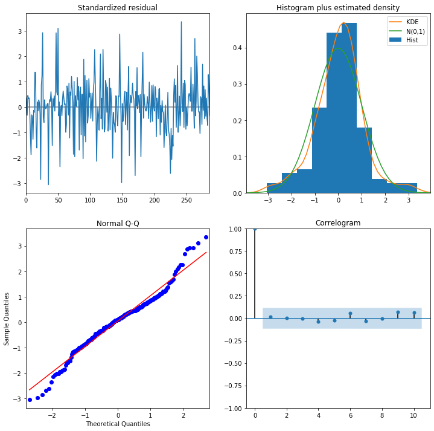

```python
# Summarize residual errors for the automated grid search ARIMA model
print(randgrid_results.summary())
randgrid_results.plot_diagnostics(figsize=(12,12))
plt.show()
```

```python
if (notifyStatus): email_notify("ARIMA automated random search completed! "+datetime.now().strftime('%a %B %d, %Y %I:%M:%S %p'))
```

```python
# Do an automated grid search of ARIMA parameters
# if (seasonal_freq == 0):
#     autogrid_results = pm.auto_arima(train_ts, start_p = start_p, d = start_d, start_q = start_q, max_p = max_p, max_d = max_d, max_q = max_q,
#                                      seasonal = False, stepwise = False, max_order = None, trace = True, suppress_warnings = True, random_state = seedNum)
# else:
#     autogrid_results = pm.auto_arima(train_ts, start_p = start_p, d = start_d, start_q = start_q, max_p = max_p, max_d = max_d, max_q = max_q,
#                                      seasonal = True, m = seasonal_freq, start_P = start_P, D = start_D, start_Q = start_Q, max_P = max_P, max_D = max_D, max_Q = max_Q,
#                                      stepwise = False, max_order = None, trace = True, suppress_warnings = True, random_state = seedNum)
```

```python
# Summarize residual errors for the automated grid search ARIMA model
# print(autogrid_results.summary())
# autogrid_results.plot_diagnostics(figsize=(12,12))
# plt.show()
```

```python
if (notifyStatus): email_notify("ARIMA automated grid search completed! "+datetime.now().strftime('%a %B %d, %Y %I:%M:%S %p'))
```

```python
# Not applicable for this iteration of the project

# Set up the function to handle the ARIMA calculation
# def Calculate_ARIMA(ns_order, ss_order):
#     startTimeModel = datetime.now()
#     aic_score, bic_score = float("inf"), float("inf")
#     if (verbose): print('Trying to fit the model with parameters:', ns_order, ss_order)
#     try:
#         if (ss_order[3] == 0): grid_model = SARIMAX(train_ts, order=ns_order)
#         else: grid_model = SARIMAX(train_ts, order=ns_order, seasonal_order=ss_order)
#         with warnings.catch_warnings():
#             warnings.simplefilter("ignore")
#             grid_results = grid_model.fit(disp = False)
#         aic_score = grid_results.aic
#         bic_score = grid_results.bic
#         if (verbose): print('Fit ARIMA: order=%s seasonal_order=%s; AIC=%.3f, BIC=%.3f, Fit time=%s' %
#               (ns_order, ss_order, aic_score, bic_score, (datetime.now() - startTimeModel)))
#         return(aic_score, bic_score)
#     except:
#         return(float("inf"), float("inf"))
```

```python
# Not applicable for this iteration of the project

# Do a manual grid search of ARIMA parameters
# best_score, best_ns_cfg, best_ss_cfg = float("inf"), None, None
# for p in range(start_p, max_p+1):
#     for d in range(start_d, max_d+1):
#         for q in range(start_q, max_q+1):
#             for P in range(start_P, max_P+1):
#                 for D in range(start_D, max_D+1):
#                     for Q in range(start_Q, max_Q+1):
#                         ns_order = (p, d, q)
#                         ss_order = (P, D, Q, seasonal_freq)
#                         aic_score, bic_score = Calculate_ARIMA(ns_order, ss_order)
#                         if (aic_score < best_score):
#                             best_ns_cfg, best_ss_cfg, best_score = ns_order, ss_order, aic_score
#                             print('A better model found: order=%s seasonal_order=%s; AIC=%.3f, BIC=%.3f' % (ns_order, ss_order, aic_score, bic_score))
# print('Best ARIMA model via manual search: order=%s seasonal_order=%s; AIC=%f' % (best_ns_cfg, best_ss_cfg, best_score))
```

```python
# Summarize residual errors for the manual ARIMA model
# manual_model = SARIMAX(train_ts, order=best_ns_cfg, seasonal_order=best_ss_cfg)
# manual_results = manual_model.fit(disp = False)
# print(manual_results.summary())
# manual_results.plot_diagnostics(figsize=(12,12))
# plt.show()
```

```python
if (notifyStatus): email_notify("ARIMA Hyperparameters Search completed! "+datetime.now().strftime('%a %B %d, %Y %I:%M:%S %p'))
```

### 4.c) Evaluate the Residual Errors

A good final check of a model is to review residual forecast errors. Ideally, the distribution of residual errors should be a Gaussian with a zero mean.

```python
# Set the ARIMA order parameters for validation and forecasting
final_ns_order = stepwise_results.order
# final_ns_order = randgrid_results.order
# final_ns_order = autogrid_results.order
# final_ns_order = best_ns_cfg
if (seasonal_freq != 0):
    final_ss_order = stepwise_results.seasonal_order
#     final_ss_order = randgrid_results.seasonal_order
#     final_ss_order = autogrid_results.seasonal_order
#     final_ss_order = best_ss_cfg
    print("Final Non-season order:", final_ns_order, 'Final Seasonal Order:', final_ss_order)
else:
    print("Final Non-season order:", final_ns_order)
```

```
Final Non-season order: (1, 1, 1) Final Seasonal Order: (2, 0, 1, 12)
```

```
                                     SARIMAX Results
==========================================================================================
Dep. Variable:                              value   No. Observations:                  360
Model:             SARIMAX(1, 1, 1)x(2, 0, 1, 12)   Log Likelihood                -785.118
Date:                            Tue, 25 Feb 2020   AIC                           1582.237
Time:                                    03:47:16   BIC                           1605.536
Sample:                                01-01-1990   HQIC                          1591.502
                                     - 12-01-2019
Covariance Type:                              opg
==============================================================================
                 coef    std err          z      P>|z|      [0.025      0.975]
------------------------------------------------------------------------------
ar.L1          0.9365      0.046     20.364      0.000       0.846       1.027
ma.L1         -0.8365      0.070    -12.024      0.000      -0.973      -0.700
ar.S.L12       1.0687      0.063     16.935      0.000       0.945       1.192
ar.S.L24      -0.0717      0.062     -1.153      0.249      -0.194       0.050
ma.S.L12      -0.8577      0.047    -18.294      0.000      -0.950      -0.766
sigma2         4.2640      0.271     15.753      0.000       3.733       4.795
===================================================================================
Ljung-Box (Q):                       42.42   Jarque-Bera (JB):                27.80
Prob(Q):                              0.37   Prob(JB):                         0.00
Heteroskedasticity (H):               0.67   Skew:                             0.14
Prob(H) (two-sided):                  0.03   Kurtosis:                         4.33
===================================================================================

Warnings:
[1] Covariance matrix calculated using the outer product of gradients (complex-step).
```

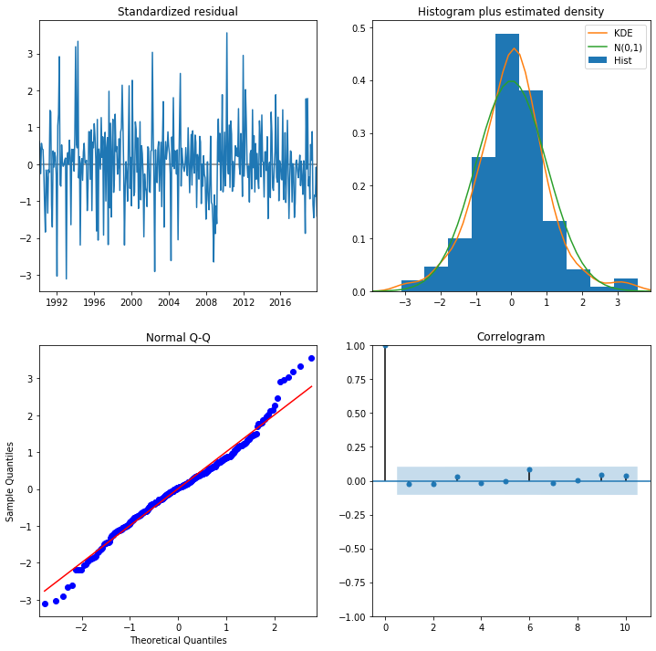

```python
# Summarize residual errors for the final ARIMA model
if (seasonal_freq != 0):
    final_model = SARIMAX(time_series, order=final_ns_order, seasonal_order=final_ss_order)
else:
    final_model = SARIMAX(time_series, order=final_ns_order)
final_results = final_model.fit(disp = False)
print(final_results.summary())
final_results.plot_diagnostics(figsize=(12,12))
plt.show()
```

```python
if (notifyStatus): email_notify("Model Fitting and Evaluation completed! "+datetime.now().strftime('%a %B %d, %Y %I:%M:%S %p'))
```

## Section 5. Finalize Model

After models have been developed and a final model selected, it must be validated and finalized. Validation is an optional part of the process, but one that provides a ‘last check’ to ensure we have not fooled or lied to ourselves.

```python
if (notifyStatus): email_notify("Model Finalization has begun! "+datetime.now().strftime('%a %B %d, %Y %I:%M:%S %p'))
```

### 5.a) Validation via In-sample Data

```python
validate_forecast = final_results.get_prediction(start = -test_size)
mean_validate_forecast = validate_forecast.predicted_mean
validate_confidence_intervals = validate_forecast.conf_int()
```

```python
# Occasionally some predicted values turned out to be < 0 but they should not be (e.g. rainfall, disease cases, etc.)
# If we have those values, we will need to set them to 0
# print(mean_validate_forecast[mean_validate_forecast < 0])
# mean_validate_forecast[mean_validate_forecast < 0] = 0
```

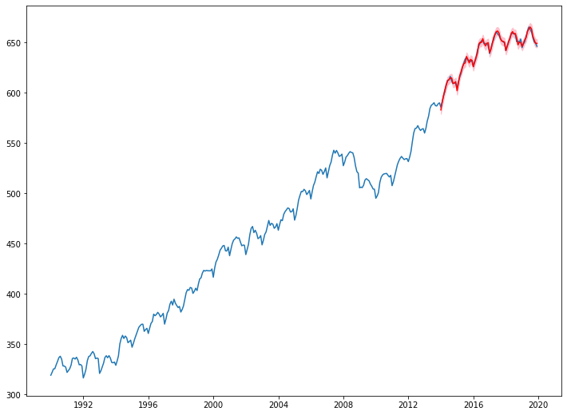

```python
plt.figure(figsize=(12,9))
plt.plot(time_series.index, time_series[target_col], label='observed')
plt.plot(mean_validate_forecast.index, mean_validate_forecast.values, color='red', label='forecast')
plt.fill_between(validate_confidence_intervals.index, validate_confidence_intervals[lower_bound],
                 validate_confidence_intervals[upper_bound], color='pink')
plt.show()
```

```python
# Evaluate RMSE for the validation data
y_test = time_series[-test_size:]
predictions = mean_validate_forecast.values
for i in range(y_test.shape[0]):
    print(y_test.index[i], ' | ', y_test.iloc[i,0], ' | ', predictions[i])
print('RMSE from the validation data is: %.3f' % math.sqrt(mean_squared_error(y_test, predictions)))
```

```
2014-01-01 00:00:00  |  585.8  |  583.0457496364415
2014-02-01 00:00:00  |  591.2  |  591.0454065122556
2014-03-01 00:00:00  |  597.0  |  596.9002326611767
2014-04-01 00:00:00  |  601.1  |  602.9407211653476
2014-05-01 00:00:00  |  608.2  |  607.5136801807029
2014-06-01 00:00:00  |  612.6  |  611.9067017763043
2014-07-01 00:00:00  |  612.8  |  613.1551298928745
2014-08-01 00:00:00  |  616.4  |  614.863472498266
2014-09-01 00:00:00  |  611.8  |  614.851045314709
2014-10-01 00:00:00  |  609.2  |  609.5057694370793
2014-11-01 00:00:00  |  609.9  |  609.786672036376
2014-12-01 00:00:00  |  609.3  |  611.1734528244231
2015-01-01 00:00:00  |  605.1  |  602.188243684456
2015-02-01 00:00:00  |  611.7  |  609.9943444761976
2015-03-01 00:00:00  |  615.8  |  617.1142035473827
2015-04-01 00:00:00  |  619.6  |  621.070895034585
2015-05-01 00:00:00  |  625.5  |  625.7551338324487
2015-06-01 00:00:00  |  629.7  |  629.0140099822912
2015-07-01 00:00:00  |  633.7  |  629.8146727787504
2015-08-01 00:00:00  |  635.5  |  636.2298999416663
2015-09-01 00:00:00  |  632.3  |  633.3049115567394
2015-10-01 00:00:00  |  632.5  |  629.8691394053193
2015-11-01 00:00:00  |  631.3  |  633.3492689487205
2015-12-01 00:00:00  |  632.5  |  632.3060126037651
2016-01-01 00:00:00  |  626.1  |  626.108064403643
2016-02-01 00:00:00  |  630.5  |  631.3199698485117
2016-03-01 00:00:00  |  634.5  |  635.3801930366715
2016-04-01 00:00:00  |  642.4  |  639.354086523274
2016-05-01 00:00:00  |  646.7  |  648.6819608716041
2016-06-01 00:00:00  |  649.3  |  650.3586124015744
2016-07-01 00:00:00  |  651.9  |  650.1331795967424
2016-08-01 00:00:00  |  651.8  |  653.9457827649919
2016-09-01 00:00:00  |  648.9  |  649.1901530796711
2016-10-01 00:00:00  |  649.2  |  646.7436088733048
2016-11-01 00:00:00  |  648.9  |  649.3634437941198
2016-12-01 00:00:00  |  646.9  |  649.9436802446971
2017-01-01 00:00:00  |  639.2  |  639.9396995430767
2017-02-01 00:00:00  |  644.4  |  643.6572019384485
2017-03-01 00:00:00  |  649.5  |  648.8353826752832
2017-04-01 00:00:00  |  652.8  |  654.9186321401869
```

[output cut: 18 more lines]

```
2018-11-01 00:00:00  |  650.4  |  650.6697729103925
2018-12-01 00:00:00  |  653.6  |  649.9193522281006
2019-01-01 00:00:00  |  645.1  |  646.3213081719571
2019-02-01 00:00:00  |  648.8  |  649.5194892930944
2019-03-01 00:00:00  |  650.8  |  652.7412935798496
2019-04-01 00:00:00  |  656.2  |  655.0973895051836
2019-05-01 00:00:00  |  661.3  |  661.0821518386527
2019-06-01 00:00:00  |  665.5  |  663.6752229642607
2019-07-01 00:00:00  |  663.3  |  665.5494469144854
2019-08-01 00:00:00  |  660.7  |  663.6982362256467
2019-09-01 00:00:00  |  654.7  |  656.4295188618137
2019-10-01 00:00:00  |  650.7  |  652.4982171665827
2019-11-01 00:00:00  |  649.3  |  649.4644769622038
2019-12-01 00:00:00  |  646.4  |  649.308731550186
RMSE from the validation data is: 1.740
```

### 5.b) Forecasting Out-of-Sample Data

```python
forecast_size = seasonal_freq
final_forecast = final_results.get_forecast(steps = forecast_size)
mean_final_forecast = final_forecast.predicted_mean
final_confidence_intervals = final_forecast.conf_int()
print("The forecasted values are:\n\n", mean_final_forecast)
```

```
The forecasted values are:

 2020-01-01    637.997727
2020-02-01    641.476641
2020-03-01    644.418268
2020-04-01    648.489784
2020-05-01    652.947218
2020-06-01    655.314775
2020-07-01    654.305068
2020-08-01    653.763564
2020-09-01    649.255222
2020-10-01    646.531221
2020-11-01    645.457429
2020-12-01    644.826977
Freq: MS, dtype: float64
```

```python
# Occasionally some predicted values turned out to be < 0 but they should not be (e.g. rainfall, disease cases, etc.)
# If we have those values, we will need to set them to 0
# print(mean_final_forecast[mean_final_forecast < 0])
# mean_final_forecast[mean_final_forecast < 0] = 0
```

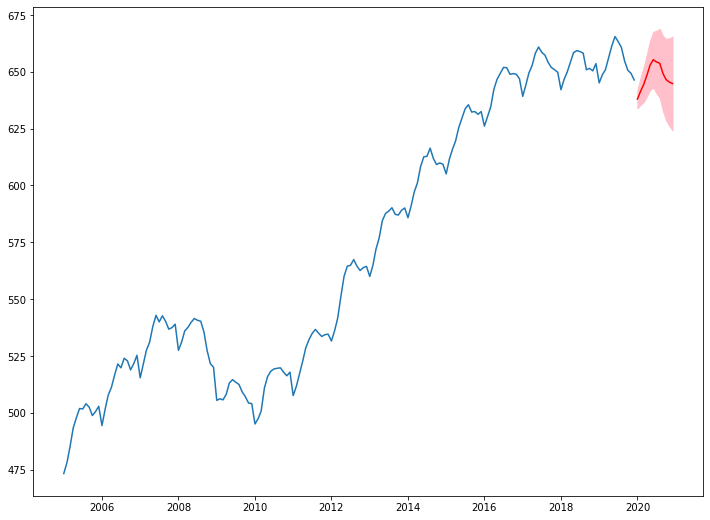

```python
plt.figure(figsize=(12,9))
halfway_point = int(time_series.index.size / 2)
plt.plot(time_series.index[halfway_point:], time_series[target_col][halfway_point:], label='observed')
plt.plot(mean_final_forecast.index, mean_final_forecast.values, color='red', label='forecast')
plt.fill_between(final_confidence_intervals.index, final_confidence_intervals[lower_bound],
                 final_confidence_intervals[upper_bound], color='pink')
plt.show()
```

```python
if (notifyStatus): email_notify("Model Finalization completed! "+datetime.now().strftime('%a %B %d, %Y %I:%M:%S %p'))
```

```python
print ('Total time for the script:',(datetime.now() - startTimeScript))
```

```
Total time for the script: 0:12:15.349736
```